# Practical Machine Learning - Excercise Prediction

## Conclusion

Before doing the final prediction we will examine the chosen modelusing the variable importance plot and the error vs the number of trees, to determine if we could have improved the model significantly by increasing then umber of trees.

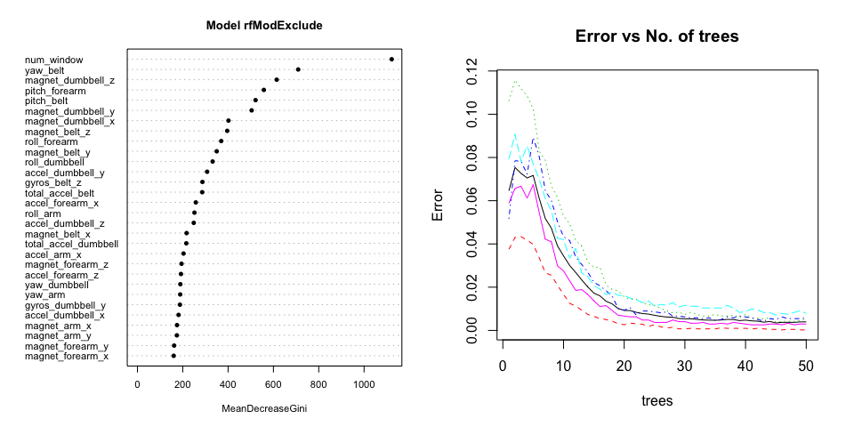

```r
par(mfrow=c(1,2))
varImpPlot(rfModExclude, cex=0.7, pch=16, main='Model rfModExclude')
plot(rfModExclude, , cex=0.7, main='Error vs No. of trees')
```

```r
par(mfrow=c(1,1))
```

The variable importance plot which represents the mean decrease in node impurity (and not the mean decrease in accuracy) could be futher explored by visualizing Partial Response Plots and MultiDimensioning Scaling Plots. From the resulting plots we can see that the error trend seems stable at around 50 trees and even though we could have been more accurate with a larger number of trees it should not be a significant improvement.

# Test prediction results

Let’s look at predictions for the selected model on the final test set.

```r
predictionResult <- predict(rfModExclude, testingSet[,-excludeColumns])
predictionResult
```

```
##  1  2  3  4  5  6  7  8  9 10 11 12 13 14 15 16 17 18 19 20
##  B  A  B  A  A  E  D  B  A  A  B  C  B  A  E  E  A  B  B  B
## Levels: A B C D E
```